# IODS course project

Jadwiga Buchwald

# Chapter 1: Introduction to Open Data Science, 2017

*Key words: Rmarkdown (index.Rmd and its child .Rmd files), Github (forking, pushing), R (ggplot2, dplyr)*

## Short description of the course

This course is a Massive Open Online Course (**MOOC**) taught by *Kimmo Vehkalahti, Tuomo Nieminen, Emma Kämäräinen* and *Petteri Mäntymaa*. This course introduces us to the softwares: `R`, `Rstudio`, `Rmarkdown`, `GitHub`, `Git`/`Git Desktop`. This is what it says on the course web page about the course:

> Our era of data - larger than ever and complex like chaos - requires several skills from statisticians and other data scientists. We must discover the patterns hidden behind numbers in matrices and arrays. We are not afraid of coding, recoding, programming, or modelling. We want to visualize, analyze, interpret, understand, and communicate. These are the core themes of Open Data Science (Open Data - Open Science - Data Science). And this course is THE course for learning these skills.  
> *The above text modified from:* [here](https://www.crcpress.com/Correspondence-Analysis-in-Practice-Third-Edition/Greenacre/p/book/9781498731775?tab=rev)

## Link to my Github repository

https://github.com/JadwigaBuchwald/IODS-project

# Chapter 2: Data wrangling and linear regression

*Key words: pairwise plots, assumptions of a linear model*

Reading in the data `learning2014` that we wrangled from the data described [here](http://www.helsinki.fi/~kvehkala/JYTmooc/JYTOPKYS2-meta.txt). The data is from a Finnish statistics course based on an international survey of approaches to learning.

```r
learning2014<-read.table("./data/learning2014.txt", sep="\t", header=T, dec=".")
dim(learning2014)
```

```
## [1] 166   7
```

```r
str(learning2014)
```

```
## 'data.frame':    166 obs. of  7 variables:
##  $ gender  : Factor w/ 2 levels "F","M": 1 2 1 2 2 1 2 1 2 1 ...
##  $ age     : int  53 55 49 53 49 38 50 37 37 42 ...
##  $ attitude: num  3.7 3.1 2.5 3.5 3.7 3.8 3.5 2.9 3.8 2.1 ...
##  $ deep    : num  3.58 2.92 3.5 3.5 3.67 ...
##  $ stra    : num  3.38 2.75 3.62 3.12 3.62 ...
##  $ surf    : num  2.58 3.17 2.25 2.25 2.83 ...
##  $ points  : int  25 12 24 10 22 21 21 31 24 26 ...
```

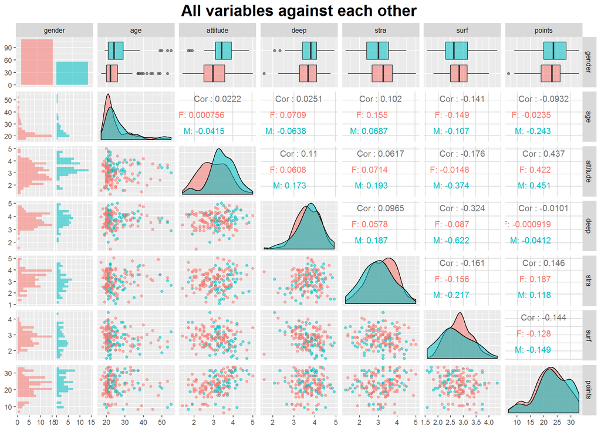

*Figure 1:Pairwise plot of all variables by sex*

```r
###Data descriptives

# accessig the GGally and ggplot2 libraries
library(GGally)
library(ggplot2)

# Drawing pairwise plots of all columnswith ggpairs(), by sex
p <- ggpairs(learning2014, mapping = aes(col=gender,alpha=0.3), lower = list(combo = wrap("facethist", bins = 20))) +
  ggtitle("All variables against each other") +
  theme(plot.title = element_text(hjust = 0.5,size=20,face='bold'))
p
```